# Problem Set 11

Aakash Ahuja

05/12/2019

**Ans 1 a) Assumtions of ANOVA under the Null Hypothesis that the Population means of weight gained for the 4 groups of rats are equal or:**
$$\mu_1=\mu_2=\mu_3=\mu_4$$

1. The observations are independent: This Assumption is met as all the 4 rat types are kept in different cages and then the measurements are taken on them.
2. The Populations are Normal. This assumption can be checked using a qqplot. We can see from the qqplots given for each category of food fed that these qqplots are almost linear. Hence Normality assumption is also met.
3. The Population variances are equal or Homoskedasticity. This assumption is also met as the sample standard deviation for all the 4 categories is roughly around 15. Since they do not differ by much, we can assume homoskedasticity.

**Ans 1 b) Pen & Paper complete Solution submitted with the assignment. R solution is below:**

```r
m1<-83.5
m2<-92.3
m3<-88.6
m4<-99.4
mean(m1,m2,m3,m4)
```

```
## [1] 83.5
```

```r
x_bar<-sum(m1,m2,m3,m4)/4
N<-140
K<-4
var1<-16.9^2
var2<-14.6^2
var3<-14.2^2
var4<-14.1^2

between.ms <- var(c(m1,m2,m3,m4)) * 35
between.ms
```

```
## [1] 1566.25
```

```r
within.ms <- sum(c(var1 * 34 , var2 * 34, var3 * 34, var4 * 34)) / (34+34+34+34)
within.ms
```

```
## [1] 224.805
```

```r
F <- between.ms / within.ms
F
```

```
## [1] 6.967149
```

```r
p_value<-1 - pf(F, df1 = 3, df2 = 136)
p_value
```

```
## [1] 0.0002140835
```

**Ans 1c** With such a small p-value of 0.0002140835, we fail to accept our null hypothesis that the population means of the 4 categories are equal. This means that the 4 groups of rats who were fed different diets gained different weights and are different from each other in terms of weight gained.

**Ans 2: 1: Checking the Boxplots and QQplots of the Hemoglobin data for the 3 categories of Sickle Cell Disease**

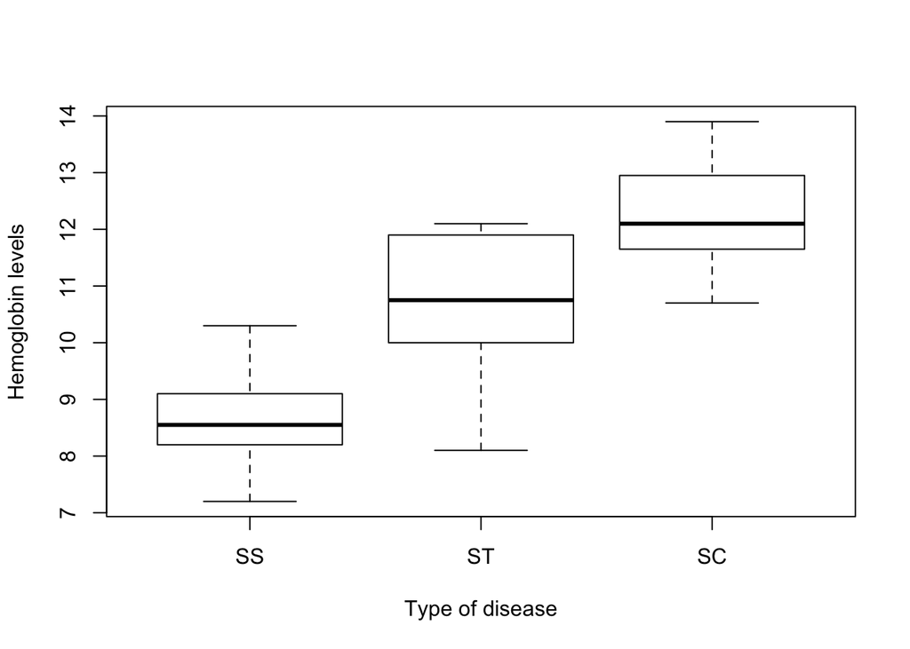

```r
SS<-c(7.2,7.7,8.0,8.1,8.3,8.4,8.4,8.5,8.6,8.7,9.1,9.1,9.1,9.8,10.1,10.3)
ST<-c(8.1,9.2,10.0,10.4,10.6,10.9,11.1,11.9,12.0,12.1)
SC<-c(10.7,11.3,11.5,11.6,11.7,11.8,12.0,12.1,12.3,12.6,12.6,13.3,13.3,13.8,13.9)
boxplot(SS,ST,SC,names=c('SS','ST','SC'),horizontal = FALSE, xlab="Type of disease", ylab="Hemoglobin levels")
```

```r
sd(SS)
```

```
## [1] 0.844492
```

```r
sd(ST)
```

```
## [1] 1.284134
```

```r
sd(SC)
```

```
## [1] 0.9418826
```

**The boxplots show that the data comes from population of categories with different means. The Homoskedasticity assumption is met as the standard deviation for the 3 categories are roughly around 1 and there is not much difference**

**Checking Normality**

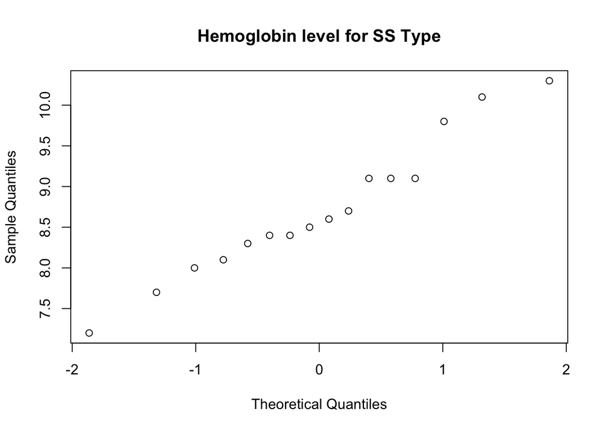

```r
qqnorm(SS,main="Hemoglobin level for SS Type")
```

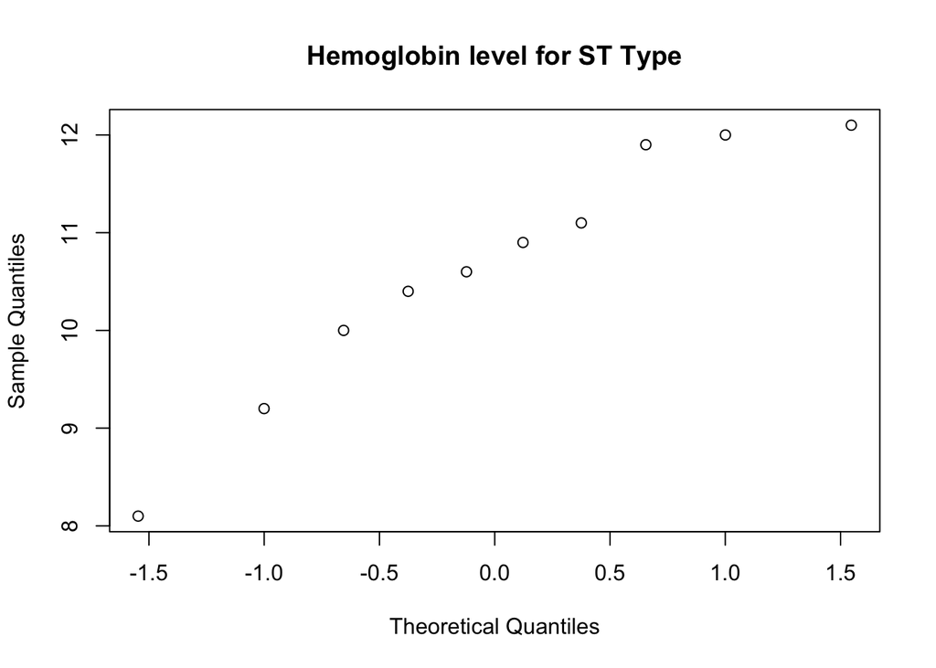

```r
qqnorm(ST,main="Hemoglobin level for ST Type")
```

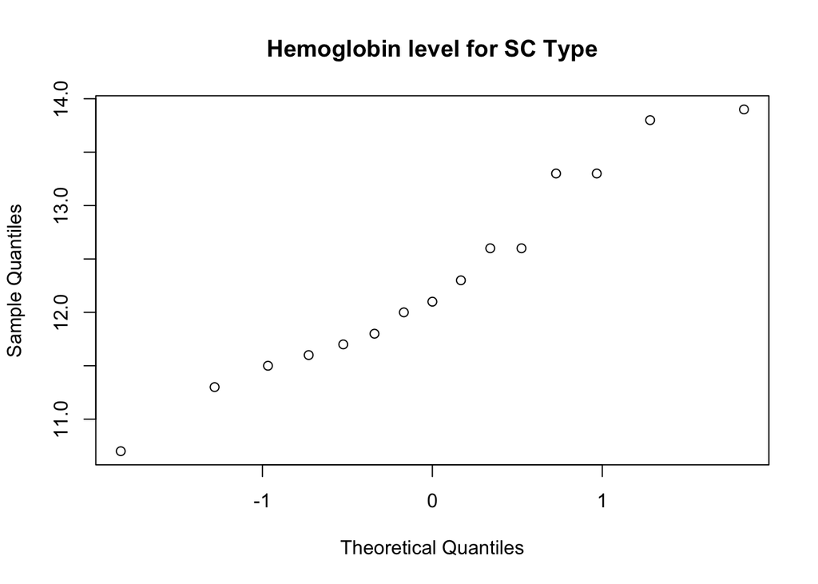

```r
qqnorm(SC,main="Hemoglobin level for SC Type")
```

**The data looks to be following a line and there no gross outliers. It may not be perfect but i think we can assume that the normality assumption is met.**

**Ans 2: 3: Our Null hypothesis is that the 3 types of sickle cell disease have the same mean hemoglobin levels**

```r
# MS Between
x1_bar<-mean(SS)
x2_bar<-mean(ST)
x3_bar<-mean(SC)
n1<-length(SS)
n2<-length(ST)
n3<-length(SC)
K<-3 # Number of categories: 3
N<-41 # Number of patients
x_bar_grand<-(x1_bar+x2_bar+x3_bar)/K
SS_between<-n1*(x1_bar-x_bar_grand)^2 + n2*(x2_bar-x_bar_grand)^2  + n3*(x3_bar-x_bar_grand)^2
df_between<-K-1
MS_between<-SS_between/df_between
MS_between
```

```
## [1] 50.00625
```

```r
#MS Within
var_x1_bar<-var(SS)
var_x2_bar<-var(ST)
var_x3_bar<-var(SC)
SS_within<-(n1-1)*var_x1_bar + (n2-1)*var_x2_bar + (n3-1)*var_x3_bar
df_within<- (N-K)
MS_within<-SS_within/df_within
MS_within
```

```
## [1] 0.9989079
```

```r
F <- MS_between / MS_within
F
```

```
## [1] 50.06092
```

```r
#using this F Statistic to calculate p-value for our Null Hypothesis.
p_value<- 1 - pf(F, df_between, df_within)
p_value
```

```
## [1] 2.243383e-11
```

**With such a small p-value we can safely reject the Null hypothesis that the 3 types of sickle cell disease have the same mean hemoglobin levels. This means that they might be different from each other. p-value doesn’t tell us by how much though. :(**

**Ans 3: 1:**

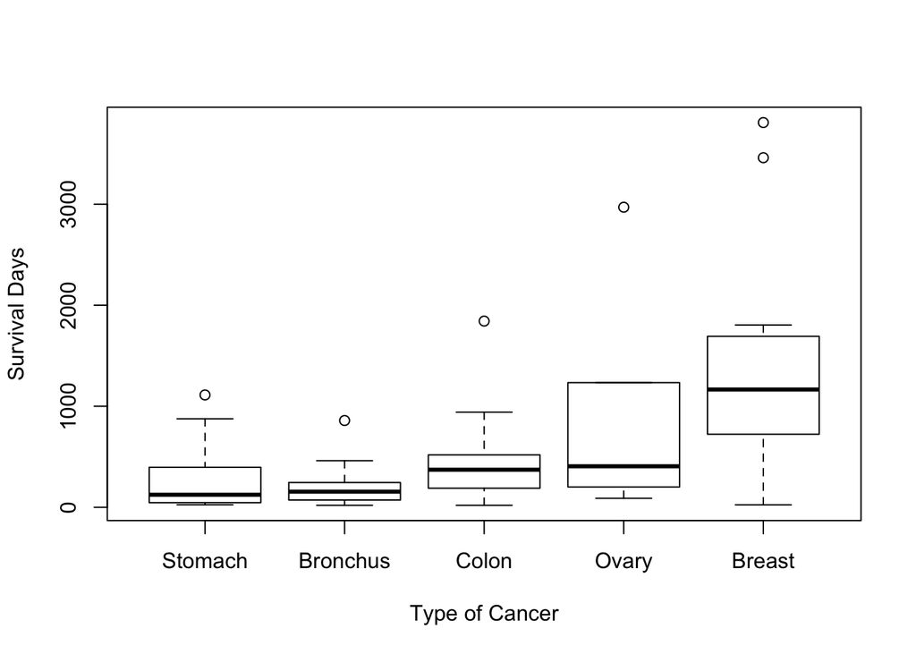

```r
Stomach<-c(124,42,25,45,412,51, 1112,46,103,876,146,340,396)
Bronchus<-c(81,461,20,450,246,166,63,64,155,859,151,166,37,223,138,72,245)
Colon<- c(248,377,189,1843,180,537,519,455,406,365,942,776,372,163,101,20,283 )
Ovary<-c(1234,89,201,356,2970,456)
Breast<-c(1235,24,1581,1166,40,727,3808,791,1804,3460,719)


#Plotting Boxplot of Untransformed Data
boxplot(Stomach,Bronchus,Colon,Ovary,Breast,names=c("Stomach","Bronchus","Colon","Ovary","Breast"),horizontal = FALSE, xlab="Type of Cancer", ylab="Survival Days")
```

**The Standard Deviations of the survival days for the 5 types of cancer are grossly dissimilar as it’s evident from the width of the boxplots. So the homoskedasticity assumption is not met. Also there are gross outliers as well. So the Normality assumption is also not met**

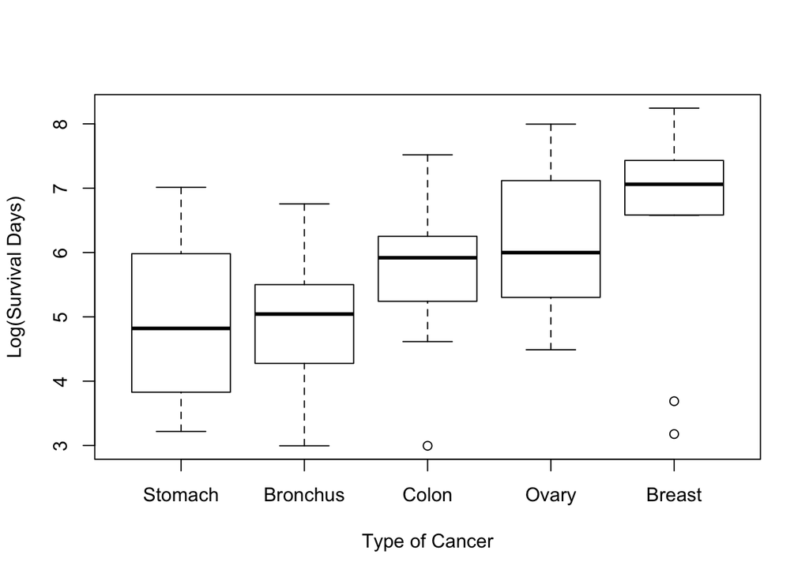

```r
y1<-log(Stomach)
y2<-log(Bronchus)
y3<-log(Colon)
y4<-log(Ovary)
y5<-log(Breast)

boxplot(y1,y2,y3,y4,y5,names=c("Stomach","Bronchus","Colon","Ovary","Breast"),horizontal = FALSE, xlab="Type of Cancer", ylab="Log(Survival Days)")
```

**Here the width of the boxplot is much better. Also the outliers seem to be much less. So here we can assume that the assumptions of the anova test of homoskedasticity and normality are met.**

**Ans 3: 2 So, We do the Anova test on the log transformed data. Here the Null Hypothesis is that the mean of log of Survival days are equal for various cancer types.**

```r
Data <- data.frame(
       Y=c(Stomach, Bronchus, Colon, Ovary,Breast),
       Type =factor(rep(c("Stomach", "Bronchus", "Colon", "Ovary","Breast"), times=c(length(Stomach), length(Bronchus), length(Colon), length(Ovary),length(Breast))))
       )
aov1 <- aov(log(Y)~Type, data=Data)
anova(aov1)
```

```
## Analysis of Variance Table
##
## Response: log(Y)
##           Df Sum Sq Mean Sq F value   Pr(>F)
## Type       4 24.487  6.1216   4.286 0.004122 **
## Residuals 59 84.270  1.4283
## ---
## Signif. codes:  0 '***' 0.001 '**' 0.01 '*' 0.05 '.' 0.1 ' ' 1
```

**With such a small p-value against a significance level of 0.05, we can safely reject the null hypothesis that the mean of log of survival days for various cancer types are same. So atleast one of the mean of log of survival days for various cancer types are different.**